# Inference interractions

# Note

Please, click on this link to get back to the Home Page.

```r
library(gllvm)
library(tidygraph)

library(corrplot)
library(gclus)
library(ggraph)
```

# Data

```r
load("BarentsFish.Rdata")

y <- as.data.frame(Data$count)

X <- as.data.frame(Data$covariates)
```

Looking at the abundance data.

```r
dim(y)
```

```
[1] 89 30
```

```r
head(y)
```

```
  Re_hi An_de An_mi Hi_pl An_lu Me_ae Ra_ra Mi_po Ar_at No_rk Lu_la Ma_vi Bo_sa
1     0     0     0    31     0   108     0   325     0     0     0     2     0
2     0     0     0     4     0   110     0   349     0     1     0     0     0
  Cy_lu Cl_ha Se_me Le_de Ga_mo Le_ma Se_ma Tr_es Ly_pa Ly_eu Ly_re Ly_se Ly_es
1     1     4     7     0    44     0    10   309     0     0     0     0     0
2     0     0    93     0   138     0     2  1041     0     0     0     0     0
  Ly_va Be_gl Ca_re Tr_spp
1     4     0     0      0
2     2     0     0      0
 [ reached 'max' / getOption("max.print") -- omitted 4 rows ]
```

Looking at the covariates.

```r
dim(X)
```

```
[1] 89  4
```

```r
str(X)
```

```
'data.frame':   89 obs. of  4 variables:
 $ Latitude   : num  71.1 71.3 71.6 71.3 71.5 ...
 $ Longitude  : num  22.4 23.7 24.9 25.9 28.1 ...
 $ Depth      : num  349 382 294 304 384 344 347 300 260 256 ...
 $ Temperature: num  3.95 3.75 3.45 3.65 3.35 3.65 3.55 3.85 2.95 3.35 ...
```

```r
summary(X)
```

```
    Latitude       Longitude         Depth        Temperature
 Min.   :70.83   Min.   :16.87   Min.   :167.0   Min.   :0.150
 1st Qu.:72.28   1st Qu.:25.88   1st Qu.:285.0   1st Qu.:1.050
 Median :73.32   Median :29.05   Median :320.0   Median :1.850
 Mean   :73.34   Mean   :28.14   Mean   :329.1   Mean   :1.887
 3rd Qu.:74.33   3rd Qu.:31.25   3rd Qu.:375.0   3rd Qu.:2.650
 Max.   :75.93   Max.   :35.60   Max.   :486.0   Max.   :4.450
```

Scaling environmental data.

```r
X <- as.data.frame(scale(X))
```

# Generalized Linear Latent Variable Model

## How does this package work?

A GLLVM model regress the mean abondance $u_{ij}$ of the specie $j$ at site $i$ as follow :

$$g(\mu_{ij}) = \eta_{ij} = \alpha_i + \beta_{0j} + x_i'\beta_j + u_i'\gamma_j$$
Where $\beta_j$ and $\gamma_j$ are vectors of species coefficient related to the covariates and to the factor loadings respectively.

Becaause there is some latent variables and factor loadings that there not observered (obvious), we estimate them with likelihood estimation.

How the algorithm work? First, `gllvm` fit a GLM model on each species. Then it computes *Randomized Quantile Residuals* also known as *Dunn-Smyth Residuals*. These residuals have the propertie to be exactly normaly distributed if model assumptions are correct (Dunn and Smyth 1996 ; Niku et al. 2019). That is why it allows the use of factor analysis using maximum-likelihood estimation to compute starting values for latent variables and factor loadings. Finaly, these values are passed into gradient based optimisation algorithms and give us back the factor loadings and latent variables values.

The residual covariance matrix stores informations about species co-occurence not explained by environmental variables computed as the product of loading matrix the transposed loading matrix.

$$\Sigma = \Gamma\Gamma'$$

Wich distribution is well suited for these data?

```r
fitp <- gllvm(y, family = poisson())

fitnb <- gllvm(y, family = "negative.binomial")
```

Look at the diagnostic plots.

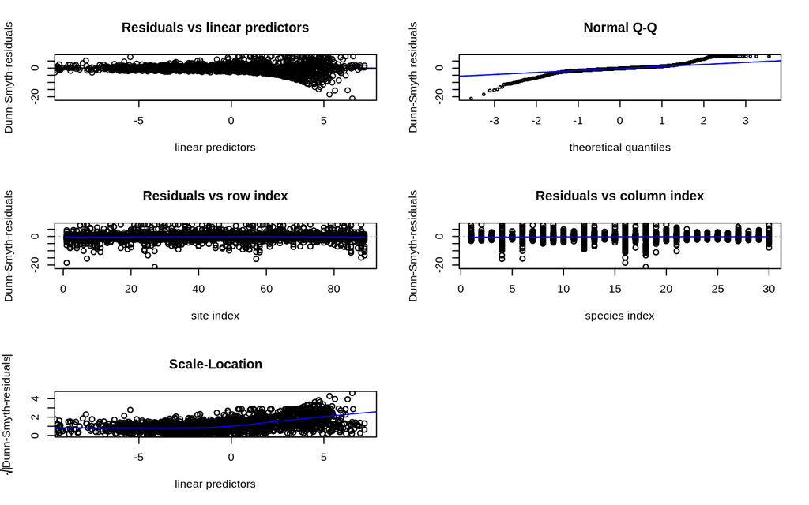

```r
par(mfrow = c(3, 2))
plot(fitp, var.colors = 1)

par(mfrow = c(3, 2))
```

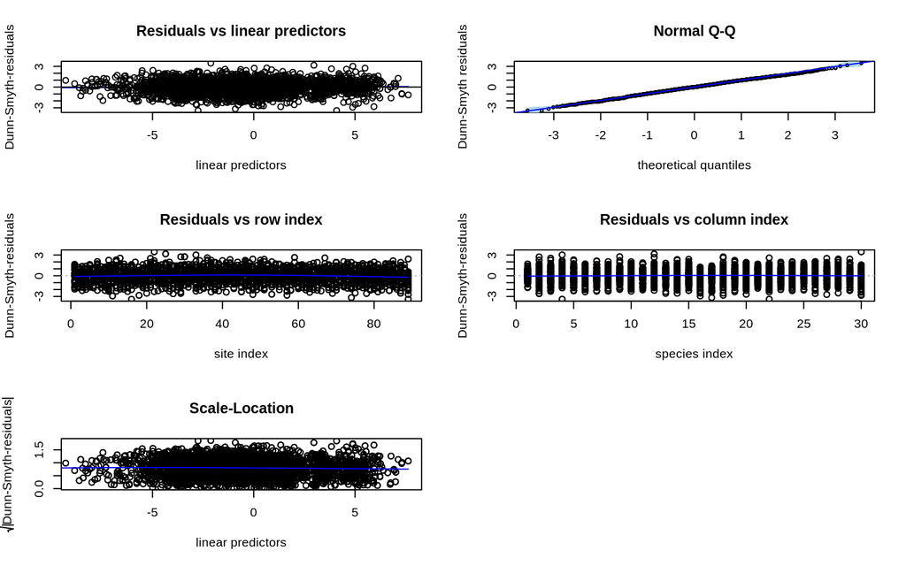

```r
plot(fitnb, var.colors = 1)
```

Using *Poisson* distirubtion there is some overdispersion and there is not when using the *Negative Binomial* distribution.

How many latent variable should we choose?

```r
AICc <- NULL
BIC <- NULL

for (i in 0:5) {

    fiti <- gllvm(y, X, family = "negative.binomial", num.lv = i, sd.errors = FALSE,
        seed = 42)

    AICc[i + 1] <- summary(fiti)$AICc
    BIC[i + 1] <- summary(fiti)$BIC

    names(AICc)[i + 1] = i
    names(BIC)[i + 1] = i
}

print("AICc")
```

```
[1] "AICc"
```

```r
print(AICc)
```

```
       0        1        2        3        4        5
8433.342 8505.994 8598.936 8683.380 8775.691 8873.218
```

```r
print("BIC")
```

```
[1] "BIC"
```

```r
print(BIC)
```

```
        0         1         2         3         4         5
 9589.558  9755.001  9953.455 10147.354 10349.389 10555.099
```

Now we create a null model with one latent variable.

```r
fit_null <- gllvm(y, family = "negative.binomial", num.lv = 1, seed = 42)
```

And now the model

```r
fit <- gllvm(y, X, family = "negative.binomial", num.lv = 1, seed = 42)
```

How much of the variance is explained by the environmental variables?

```r
1 - getResidualCov(fit)$trace/getResidualCov(fit_null)$trace
```

```
[1] 0.7735814
```

Effect of environmental variable

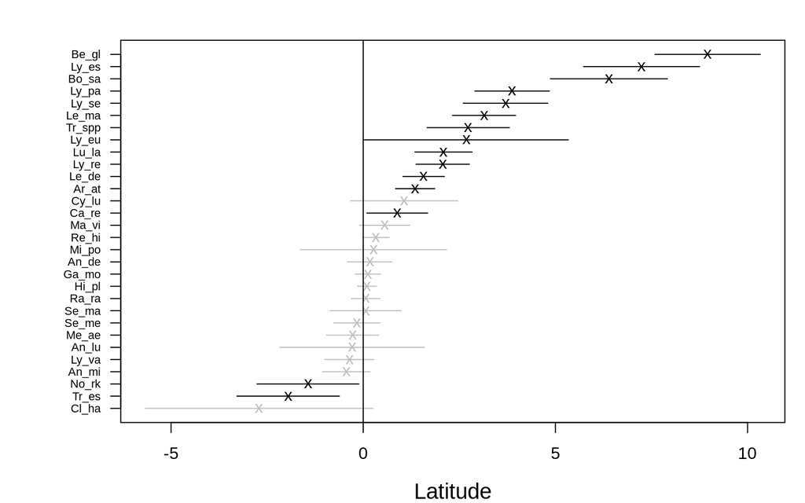

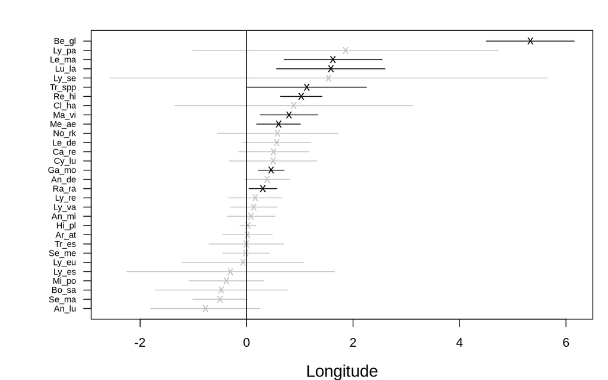

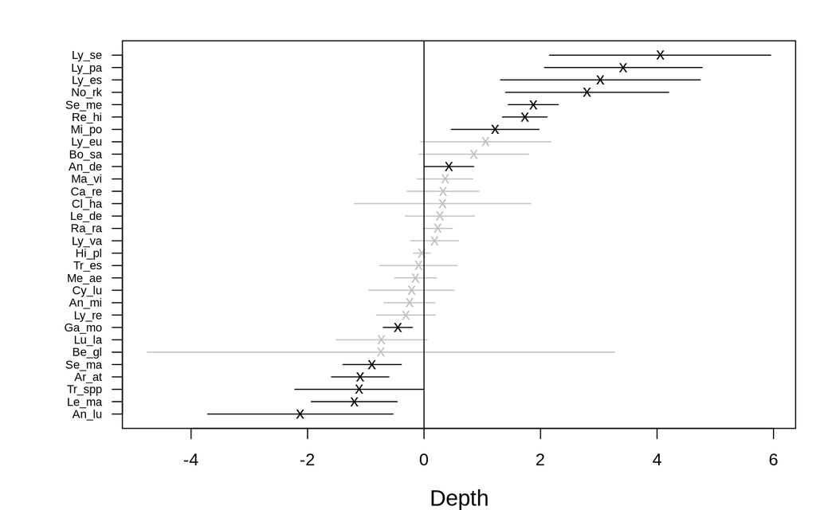

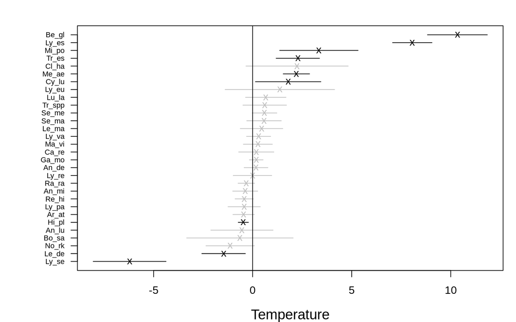

```r
coefplot(fit, cex.ylab = 0.7, mfrow = c(1, 1))
```

Most species of fish are affected by one or more environmental variable.

# Studying co-occurrence patterns

```r
cr <- getResidualCor(fit)
```

Plotting residual correlation

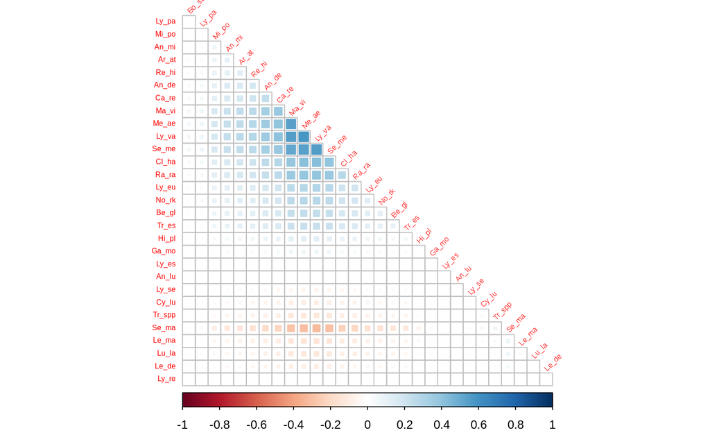

```r
corrplot(cr[order.single(cr), order.single(cr)], diag = FALSE, type = "lower", method = "square",
    tl.cex = 0.5, tl.srt = 45, tl.col = "red")
```

Not so bad at all!!!

Now I will try to create a graph from this. I will keep only the 5% most correlated data (2.5% lower bound, 2.5% upper bound).

```r
cr_sub <- cr[lower.tri(cr)]

# Now I will keep only the most extreme correlation values

cr_sub <- cr_sub[cr_sub <= quantile(cr_sub, 0.025) | cr_sub > quantile(cr_sub, 0.975)]

cr_xtr <- cr
cr_xtr[!cr_xtr %in% cr_sub] <- 0

# Now I will remove rows and columns full of 0
cr_xtr <- cr_xtr[rowSums(cr_xtr) != 0, colSums(cr_xtr) != 0]

# Create the graph
graph <- as_tbl_graph(cr_xtr)
```

And now, a graph!

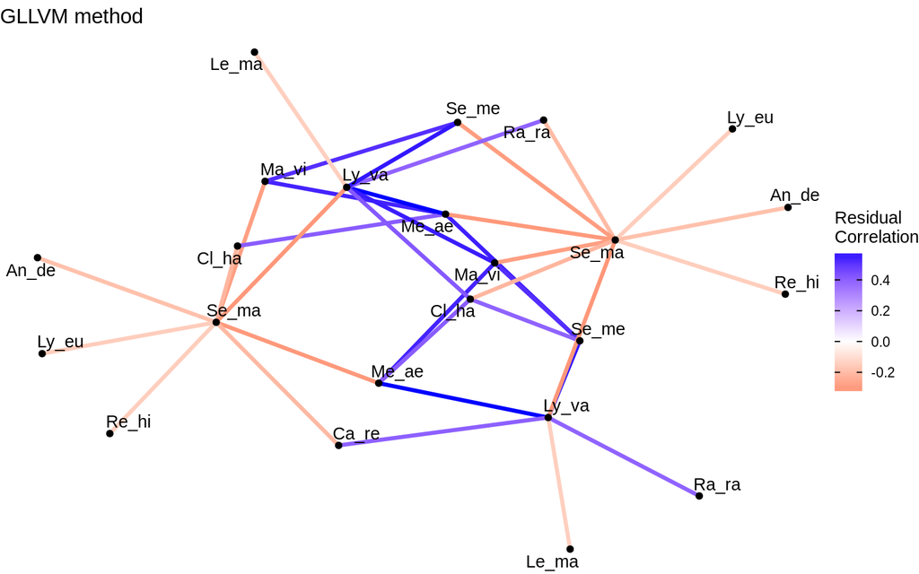

```r
gllvm_plot <- ggraph(graph, layout = "stress", ) + geom_edge_link(aes(colour = weight),
    edge_width = 1.2) + geom_node_point() + geom_node_text(aes(label = name), repel = TRUE) +
    scale_edge_color_gradient2(name = "Residual\nCorrelation", low = "red", high = "blue") +
    ggtitle("GLLVM method") + theme(panel.background = element_rect(fill = "white")) +
    theme_void()

gllvm_plot_viridis <- ggraph(graph, layout = "stress", ) + geom_edge_link(aes(colour = weight),
    edge_width = 1.2) + geom_node_point() + geom_node_text(aes(label = name), repel = TRUE) +
    scale_edge_color_viridis(name = "Residual\nCorrelation") + ggtitle("GLLVM method") +
    theme(panel.background = element_rect(fill = "white")) + theme_void()

gllvm_plot
```

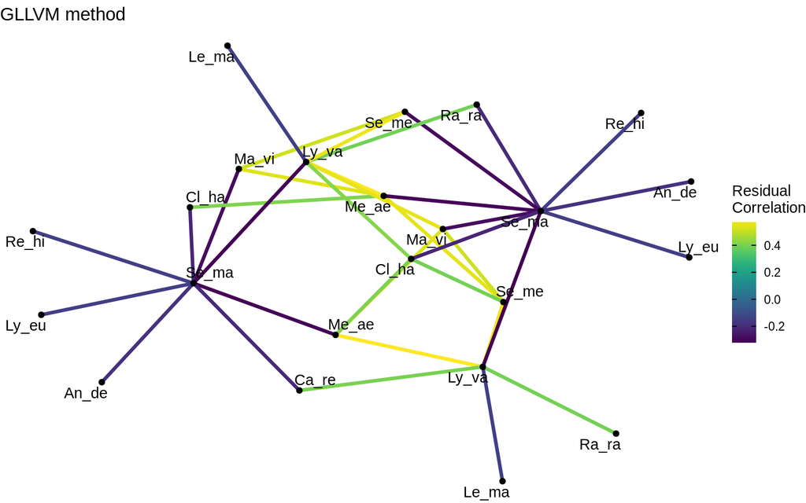

```r
gllvm_plot_viridis
```

Ok, now I will use the Robin’s model based on PLN models to reconstruct the same network. The code below come from one of his workshop. I do not understand quite well for the moment.

```r
library(PLNmodels)
library(EMtree)

# Create PLN model
plnNetAll <- PLNnetwork(as.matrix(y) ~ as.matrix(X))
```

[output not shown]

```r
plnNetAllBest <- getBestModel(plnNetAll)

plnNetAllG <- 1 * (plnNetAllBest$model_par$Omega != 0)  # We get interactions encoded by 0/1

# Compute Edge proba
treeAllWeight <- -nrow(y)/2 * log(1 - cov2cor(plnNetAllBest$model_par$Sigma)^2)
treeAllScore <- EdgeProba(treeAllWeight)
```

```
W corrected, bound= 30
```

```r
# Add convert binaries interaction into probability
graph_robin <- plnNetAllG * treeAllScore

graph_robin <- graph_robin[rowSums(graph_robin) != 0, colSums(graph_robin) != 0]

graph_robin <- as_tbl_graph(graph_robin)
```

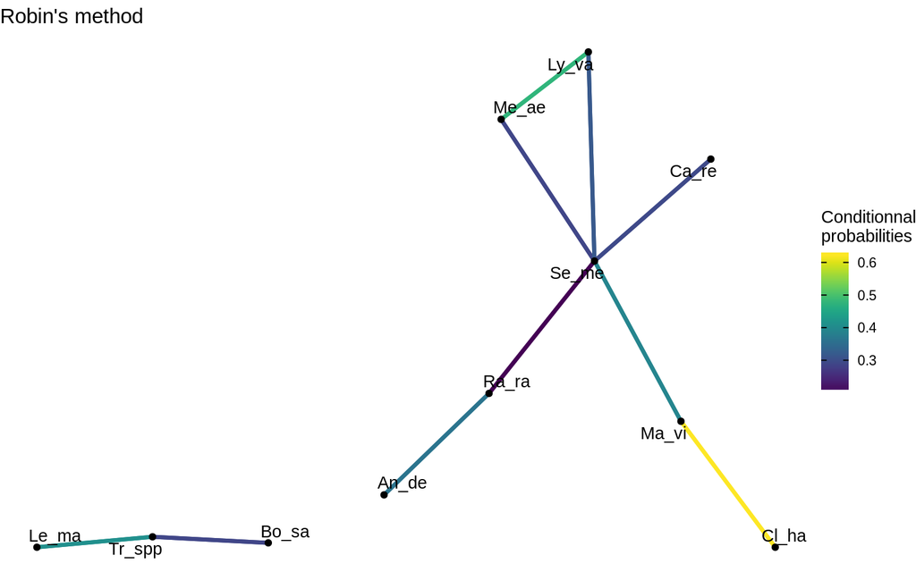

```r
robin_plot <- ggraph(graph_robin, layout = "stress", ) + geom_edge_link(aes(colour = weight),
    edge_width = 1.2) + geom_node_point() + geom_node_text(aes(label = name), repel = TRUE) +
    scale_edge_color_viridis(name = "Conditionnal\nprobabilities") + ggtitle("Robin's method") +
    theme(panel.background = element_rect(fill = "white")) + theme_void()

robin_plot
```

Comparing the two infered graph

```r
# Number of links
graph %>% activate(edges) %>% as_tibble() %>% nrow()
```

```
[1] 36
```

```r
graph_robin %>% activate(edges) %>% as_tibble() %>% nrow()
```

```
[1] 20
```

Ok, so the `gllvm` method seem to infer more link compare to Robin’s method (when I remove loops).

How many nodes are predicted by `gllvm` and Robin’s method?

```r
## Extract the name of species GLLVM
node_name_gllvm <- graph %>% activate(nodes) %>% as_tibble() %>% mutate(id = 1:nrow(.)) %>%
    mutate(id = as.character(.$id))

# Get a named vector for replacement
node_name_gllvm_vector <- node_name_gllvm$name %>% `names<-`(node_name_gllvm$id)

# Robin's Method
node_name_robin <- graph_robin %>% activate(nodes) %>% as_tibble() %>% mutate(id = 1:nrow(.)) %>%
    mutate(id = as.character(.$id))

# Get a named vector for replacement
node_name_robin_vector <- node_name_robin$name %>% `names<-`(node_name_robin$id)

# Compare species found by each metho
node_name_robin_vector[!node_name_robin_vector %in% node_name_gllvm_vector]
```

```
       5       11
 "Bo_sa" "Tr_spp"
```

```r
node_name_gllvm_vector[!node_name_gllvm_vector %in% node_name_robin_vector]
```

```
      1       9      10      13      21      22
"Re_hi" "Se_ma" "Ly_eu" "Re_hi" "Se_ma" "Ly_eu"
```

```r
unname(node_name_robin_vector[node_name_robin_vector %in% node_name_gllvm_vector])
```

```
[1] "An_de" "Me_ae" "Ra_ra" "Ma_vi" "Cl_ha" "Se_me" "Le_ma" "Ly_va" "Ca_re"
```

```r
## GLLVM Convert ID to species names
network_gllvm <- graph %>% activate(edges) %>% as_tibble() %>% select(from, to) %>%
    mutate(from = as.character(from), to = as.character(to)) %>% mutate(from = stringr::str_replace_all(.$from,
    rev(node_name_gllvm_vector)), to = stringr::str_replace_all(.$to, rev(node_name_gllvm_vector)))  # Use rev() otherwise, there 11 id is replace by 'Re_hiRe_hi' and not by 'Ly_va'

## Robin's Method Convert ID to species names
network_robin <- graph_robin %>% activate(edges) %>% as_tibble() %>% select(from,
    to) %>% mutate(from = as.character(from), to = as.character(to)) %>% mutate(from = stringr::str_replace_all(.$from,
    rev(node_name_robin_vector)), to = stringr::str_replace_all(.$to, rev(node_name_robin_vector)))  # Use rev() otherwise, there 11 id is replace by 'Re_hiRe_hi' and not by 'Ly_va'

network_gllvm[(network_gllvm$from %in% network_robin$from & network_gllvm$to %in%
    network_robin$to) | (network_gllvm$to %in% network_robin$from & network_gllvm$from %in%
    network_robin$to), ]
```

```
# A tibble: 19 x 2
   from  to
   <chr> <chr>
 1 Me_ae Ma_vi
 2 Me_ae Cl_ha
 3 Me_ae Ly_va
 4 Ra_ra Ly_va
 5 Ma_vi Me_ae
 6 Ma_vi Se_me
 7 Cl_ha Me_ae
 8 Se_me Me_ae
 9 Se_me Ma_vi
10 Se_me Cl_ha
11 Se_me Ly_va
12 Le_ma Ly_va
13 Ly_va Me_ae
14 Ly_va Ra_ra
15 Ly_va Ma_vi
16 Ly_va Cl_ha
17 Ly_va Se_me
18 Ly_va Le_ma
19 Ca_re Ly_va
```

```r
network_gllvm_vector <- network_gllvm %>% mutate(from_to = paste(.$from, .$to), to_from = paste(.$to,
    .$from)) %>% select(from_to, to_from) %>% unlist(use.names = FALSE)

network_robin_vector <- network_robin %>% mutate(from_to = paste(.$from, .$to), to_from = paste(.$to,
    .$from)) %>% select(from_to, to_from) %>% unlist

sum(network_gllvm_vector %in% network_robin_vector)
```

```
[1] 14
```

```r
sum(network_gllvm_vector %in% network_robin_vector)/(length(network_gllvm_vector) +
    length(network_robin_vector))
```

```
[1] 0.125
```

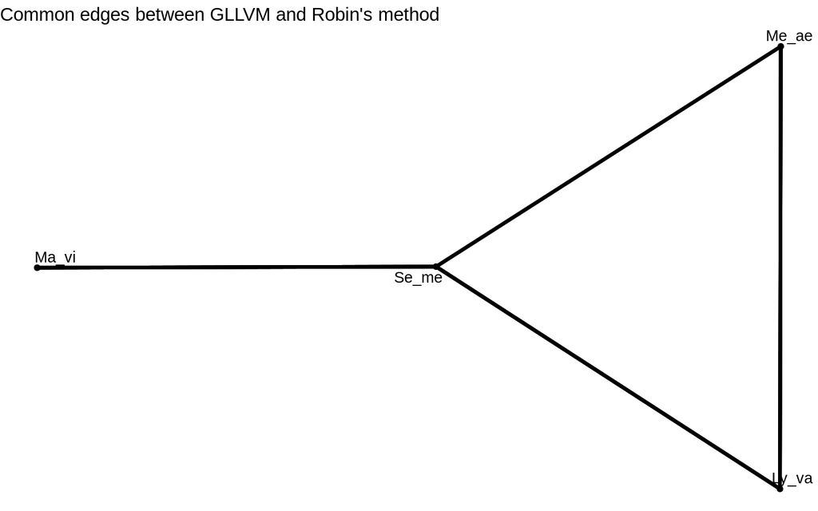

```r
network_common <- stringr::str_split_fixed(network_gllvm_vector[network_gllvm_vector %in%
    network_robin_vector], " ", n = 2)

graph_common <- as_tbl_graph(network_common)

common_plot <- ggraph(graph_common, layout = "stress", ) + geom_edge_link(edge_width = 1.2) +
    geom_node_point() + geom_node_text(aes(label = name), repel = TRUE) + scale_edge_color_viridis() +
    ggtitle("Common edges between GLLVM and Robin's method") + theme(panel.background = element_rect(fill = "white")) +
    theme_void()

common_plot
```

# References

Dunn, Peter K., and Gordon K. Smyth. 1996. “Randomized Quantile Residuals.” *Journal of Computational and Graphical Statistics* 5 (3). JSTOR: 236. https://doi.org/10.2307/1390802.

Niku, Jenni, Wesley Brooks, Riki Herliansyah, Francis K. C. Hui, Sara Taskinen, and David I. Warton. 2019. “Efficient Estimation of Generalized Linear Latent Variable Models.” Edited by Jin Li. *PLOS ONE* 14 (5). Public Library of Science (PLoS): e0216129. https://doi.org/10.1371/journal.pone.0216129.

2020-01-27